# GO Tutorial

scRNAseq pipeline + GO (ORA and GSEA)

Author

Corentin OSTA, Azzeddine Aliliche & Anais Hluszko

# 1 Base Pipeline

## 1.1 Setup & Environment

```r
set.seed(42)

cran_pkgs <- c("Seurat", "dplyr", "ggplot2", "scales", "here")
bioc_pkgs <- c("SingleCellExperiment", "scDblFinder", "clusterProfiler", "org.Mm.eg.db", "enrichplot")

if (!requireNamespace("BiocManager", quietly = TRUE)) install.packages("BiocManager")

for (pkg in cran_pkgs) {
  if (!requireNamespace(pkg, quietly = TRUE)) install.packages(pkg)
}
for (pkg in bioc_pkgs) {
  if (!requireNamespace(pkg, quietly = TRUE)) BiocManager::install(pkg, update = FALSE, ask = FALSE)
}
```

```r
suppressPackageStartupMessages({
  library(Seurat)
  library(dplyr)
  library(ggplot2)
  library(SingleCellExperiment)
  library(scDblFinder)
  library(clusterProfiler)
  library(org.Mm.eg.db)
  library(enrichplot)
})
```

## 1.2 Directory Setup

```r
sample.name <- "brain_E18"
# Paths are built from the project root (folder containing the .Rproj) with here::here()
plot_dir    <- here::here("plots")
cache_dir   <- here::here("data", "processed_data")
data_dir    <- here::here("data", "raw_data", "raw_feature_bc_matrix")

if (!dir.exists(plot_dir))  dir.create(plot_dir, recursive = TRUE)
if (!dir.exists(cache_dir)) dir.create(cache_dir, recursive = TRUE)

if (!dir.exists(data_dir)) {
  stop(
    "Count matrix not found! Please place 'raw_feature_bc_matrix' inside 'data/raw_data/'.\n",
    "Download link: [https://www.10xgenomics.com/datasets/10-k-brain-cells-from-an-e-18-mouse-v-3-chemistry-3-standard-3-0-0](https://www.10xgenomics.com/datasets/10-k-brain-cells-from-an-e-18-mouse-v-3-chemistry-3-standard-3-0-0)"
  )
}
```

## 1.3 Base Pipeline

### 1.3.1 Base Pipeline Hyperparameters

```r
MIN_CELLS_PER_GENE <- 5      # Exclude genes detected in fewer than X cells
MIN_FEATURES_INIT  <- 200    # Initial empty-droplet cutoff (min genes/cell)
QC_MIN_GENE        <- 900    # QC cutoff: minimum unique genes detected per cell
QC_MIN_UMI         <- 900    # QC cutoff: minimum total UMI counts per cell
QC_MAX_MITO_PCT    <- 15     # QC cutoff: maximum mitochondrial RNA percentage (%)
N_VARIABLE_GENES   <- 2000   # Number of Highly Variable Genes (HVGs) for PCA
N_PCS              <- 14     # Number of Principal Components kept for SNN & UMAP
CLUSTER_RES        <- 0.2    # Louvain clustering resolution (higher = more clusters)
DE_MIN_PCT         <- 0.2    # DE: test genes expressed in at least X% of cells
DE_ONLY_POS        <- FALSE  # FALSE keeps both upregulated (>0) and downregulated (<0) genes
```

### 1.3.2 Execution

```r
sobj_cache_file <- file.path(cache_dir, "sobj_processed.rds")
de_cache_file   <- file.path(cache_dir, "result_DE.rds")

if (file.exists(sobj_cache_file) && file.exists(de_cache_file)) {
  message("Loading pre-computed Seurat object and DE table from 'data/processed_data/'...")
  sobj_filtrd <- readRDS(sobj_cache_file)
  result.DE   <- readRDS(de_cache_file)
} else {
  message("Running base pipeline from scratch (results will be cached in 'data/processed_data/')...")

  # Import & Initial Seurat Object
  scmat <- Read10X(data_dir)
  sobj  <- CreateSeuratObject(counts = scmat, min.cells = MIN_CELLS_PER_GENE, min.features = MIN_FEATURES_INIT, project = sample.name)
  rm(scmat); invisible(gc())

  # Quality Control & Doublet Removal
  sobj$percent_mt <- PercentageFeatureSet(sobj, pattern = "^mt-")
  p_qc <- VlnPlot(sobj, features = c("nFeature_RNA", "nCount_RNA", "percent_mt"), ncol = 3, pt.size = 0)
  ggsave(file.path(plot_dir, "01_QC_violin_raw.png"), plot = p_qc, width = 10, height = 5, dpi = 300)
  print(p_qc)

  sobj_filtrd <- subset(sobj, subset = nFeature_RNA > QC_MIN_GENE & nCount_RNA > QC_MIN_UMI & percent_mt < QC_MAX_MITO_PCT)
  rm(sobj); invisible(gc())

  suppressWarnings({
    sceobj      <- as.SingleCellExperiment(sobj_filtrd)
    doublet_res <- scDblFinder(sceobj, verbose = FALSE)
  })
  sobj_filtrd$doublets.class <- doublet_res$scDblFinder.class
  sobj_filtrd <- subset(sobj_filtrd, subset = doublets.class == "singlet")
  rm(sceobj, doublet_res); invisible(gc())

  # Normalization, PCA, Clustering & UMAP
  DefaultAssay(sobj_filtrd) <- "RNA"
  sobj_filtrd <- NormalizeData(sobj_filtrd, normalization.method = "LogNormalize", verbose = FALSE)
  sobj_filtrd <- FindVariableFeatures(sobj_filtrd, selection.method = "vst", nfeatures = N_VARIABLE_GENES, verbose = FALSE)
  sobj_filtrd <- ScaleData(sobj_filtrd, verbose = FALSE)
  sobj_filtrd <- RunPCA(sobj_filtrd, features = VariableFeatures(sobj_filtrd), verbose = FALSE)

  nPC <- N_PCS
  sobj_filtrd <- FindNeighbors(sobj_filtrd, dims = 1:nPC, verbose = FALSE)
  sobj_filtrd <- FindClusters(sobj_filtrd, resolution = CLUSTER_RES, verbose = FALSE)
  sobj_filtrd <- RunUMAP(sobj_filtrd, dims = 1:nPC, verbose = FALSE)
  Idents(sobj_filtrd) <- paste0("RNA_snn_res.", CLUSTER_RES)

  # Differential Expression
  result.DE <- FindAllMarkers(sobj_filtrd, min.pct = DE_MIN_PCT, only.pos = DE_ONLY_POS, verbose = TRUE)

  # Save cache locally in data/processed_data/ (ignored by git via '/data' rule)
  saveRDS(sobj_filtrd, sobj_cache_file)
  saveRDS(result.DE, de_cache_file)
}
```

```
Loading pre-computed Seurat object and DE table from 'data/processed_data/'...
```

# 2 Base Pipeline Visualisation

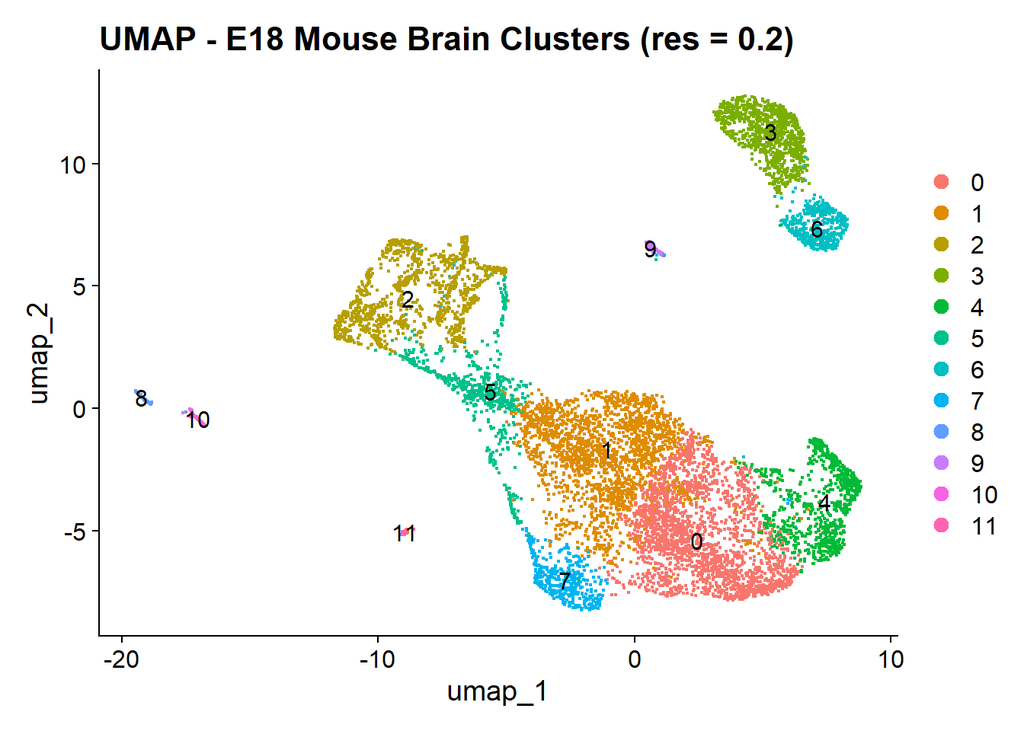

```r
p_umap <- DimPlot(sobj_filtrd, reduction = "umap", label = TRUE, pt.size = 0.3) +
  ggtitle(paste0("UMAP - E18 Mouse Brain Clusters (res = ", CLUSTER_RES, ")"))
ggsave(file.path(plot_dir, "02_UMAP_clusters.png"), plot = p_umap, width = 7, height = 5, dpi = 300)
print(p_umap)
```

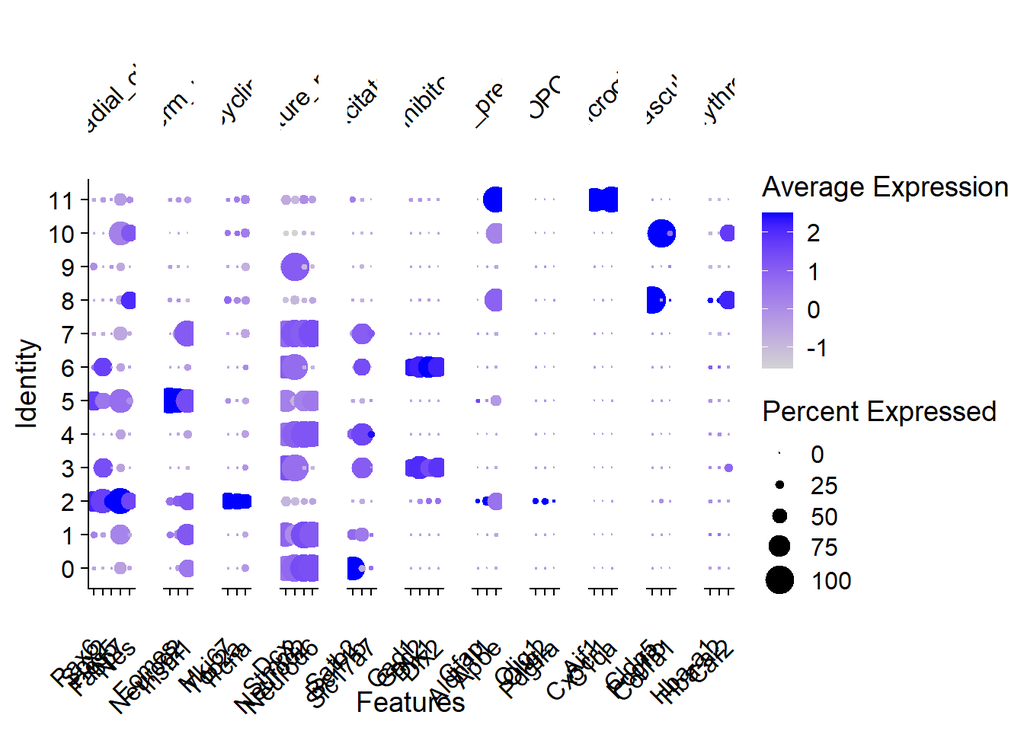

```r
marker_genes <- list(
  Radial_glia     = c("Pax6", "Sox2", "Hes5", "Fabp7", "Nes"),
  Interm_prog     = c("Eomes", "Neurog2", "Insm1"),
  Cycling         = c("Mki67", "Top2a", "Pcna"),
  Immature_neuron = c("Dcx", "Stmn2", "Neurod2", "Neurod6"),
  Excitatory      = c("Satb2", "Bcl11b", "Slc17a7"),
  Inhibitory      = c("Gad1", "Gad2", "Dlx1", "Dlx2"),
  Astro_precursor = c("Gfap", "Aldh1l1", "Apoe"),
  OPC             = c("Olig1", "Olig2", "Pdgfra"),
  Microglia       = c("Aif1", "Cx3cr1", "C1qa"),
  Vascular        = c("Cldn5", "Pdgfrb", "Col1a1"),
  Erythroid       = c("Hba-a1", "Hba-a2", "Car2")
)
marker_genes <- lapply(marker_genes, function(vec) intersect(vec, rownames(sobj_filtrd)))

p_dot_markers <- DotPlot(sobj_filtrd, features = marker_genes) +
  theme(axis.text.x = element_text(angle = 45, vjust = 0.5, hjust = 1),
        strip.text  = element_text(angle = 45, hjust = 0.5),
        plot.background = element_rect(fill = "white", color = NA))
ggsave(file.path(plot_dir, "03_DotPlot_canonical_markers.png"), plot = p_dot_markers, width = 14, height = 6, dpi = 300)
print(p_dot_markers)
```

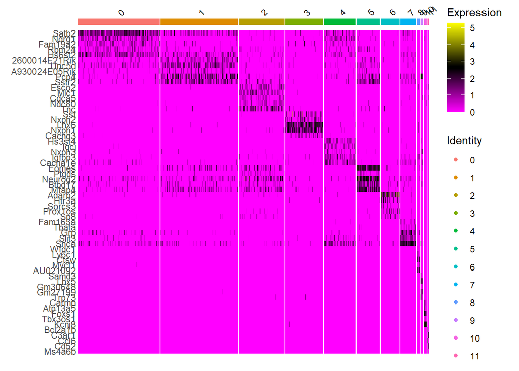

```r
top.DE <- result.DE %>% group_by(cluster) %>% slice_max(order_by = avg_log2FC, n = 5)
p_heatmap <- DoHeatmap(sobj_filtrd, slot = "data", features = unique(top.DE$gene), size = 3)
ggsave(file.path(plot_dir, "04_Heatmap_topDE.png"), plot = p_heatmap, width = 12, height = 8, dpi = 300)
print(p_heatmap)
```

### 2.0.1 Cluster Annotation Checkpoint

**Exercise**: Look at the `03_DotPlot_canonical_markers.png` plot. - Can you identify Cluster 0 based on these canonical markers? - Try to annotate the major clusters before moving to the Functional Enrichment Analysis.

**Keep your manual annotation in mind to see if the unbiased GO analysis confirms it!**

# 3 Functional Enrichment Analysis (ORA & GSEA)

## 3.1 Introduction

**Objectives**: In this section, we will translate lists of differentially expressed (DE) genes into biological understanding. You will learn how to identify which **biological pathways**, **cellular compartments**, or **molecular functions** are significantly active or repressed in a specific cell population.

We will explore two complementary methods: - **Over-Representation Analysis (ORA)**: Tests if a *filtered* list of genes (e.g., only the significant markers) has more genes associated with a specific pathway than expected by chance. - **Gene Set Enrichment Analysis (GSEA)**: Evaluates a *continuous, un-filtered* ranking of all genes to see if a pathway’s genes accumulate at the top or bottom of the list.

First, let’s select a specific cluster to analyze. Modify the `target_cluster` variable to focus on the population you annotated previously.

```r
# Select target cluster ID and validate its existence
target_cluster <- "0" # Here, we target cluster 0
stopifnot("Target cluster not found in Seurat object!" = target_cluster %in% levels(Idents(sobj_filtrd)))
```

## 3.2 Over-Representation Analysis (ORA)

ORA relies on a hypergeometric test. Imagine your cluster’s significant marker genes as a handful of marbles drawn from a large urn (the “background universe” of all expressed genes). If you draw significantly more “red marbles” (genes related to neurogenesis) than there are in the urn proportionally, that pathway is over-represented.

### 3.2.1 ORA Parameters

Before running the code, let’s address a few key parameters you can modify directly in the chunk below to explore your data:

**Filtering (UP vs DOWN)**: By default, we test UP genes (activated functions).

*Question*: Why not mix upregulated and downregulated genes together in ORA? Think about what it would mean if a pathway is enriched with a mix of activated and repressed genes—could you easily conclude on the pathway’s global state?

**The Background Universe**: We use *bg_genes <- rownames(sobj_filtrd)* (all genes detected in this specific experiment).

*Question*: What would happen if you used the whole mouse genome (~22,000 genes) as a background instead? (Hint: tissue bias).

**Ontology (ont)**: We use “BP” (Biological Process). You can change it to “MF” (Molecular Function) or “CC” (Cellular Component).

### 3.2.2 Execution

Try to run the code below line by line and explore the **ego_ora** object. Notice how the hyperparameter variables at the top allow you to easily change the conditions of the test.

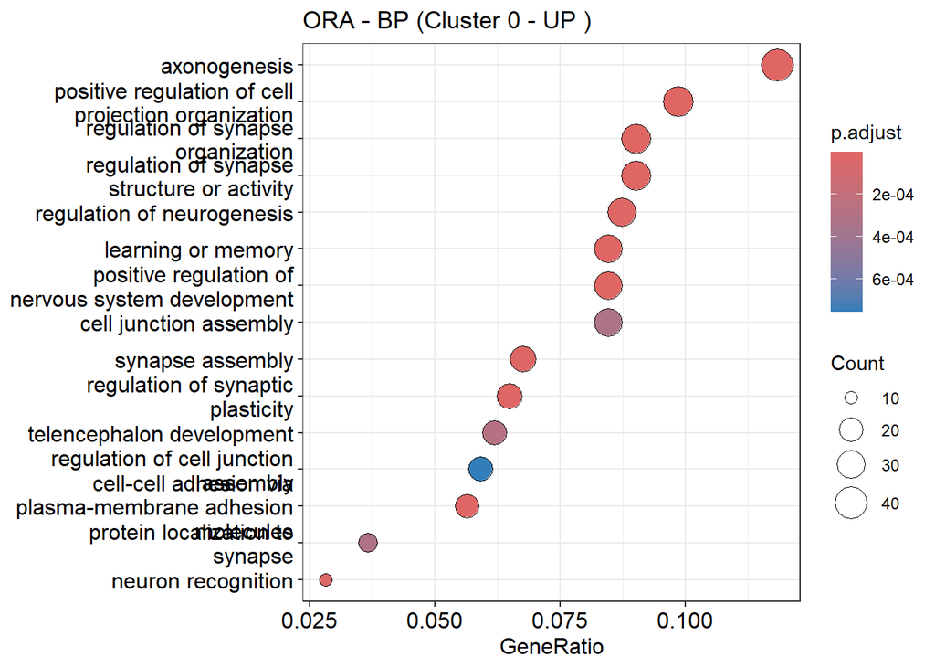

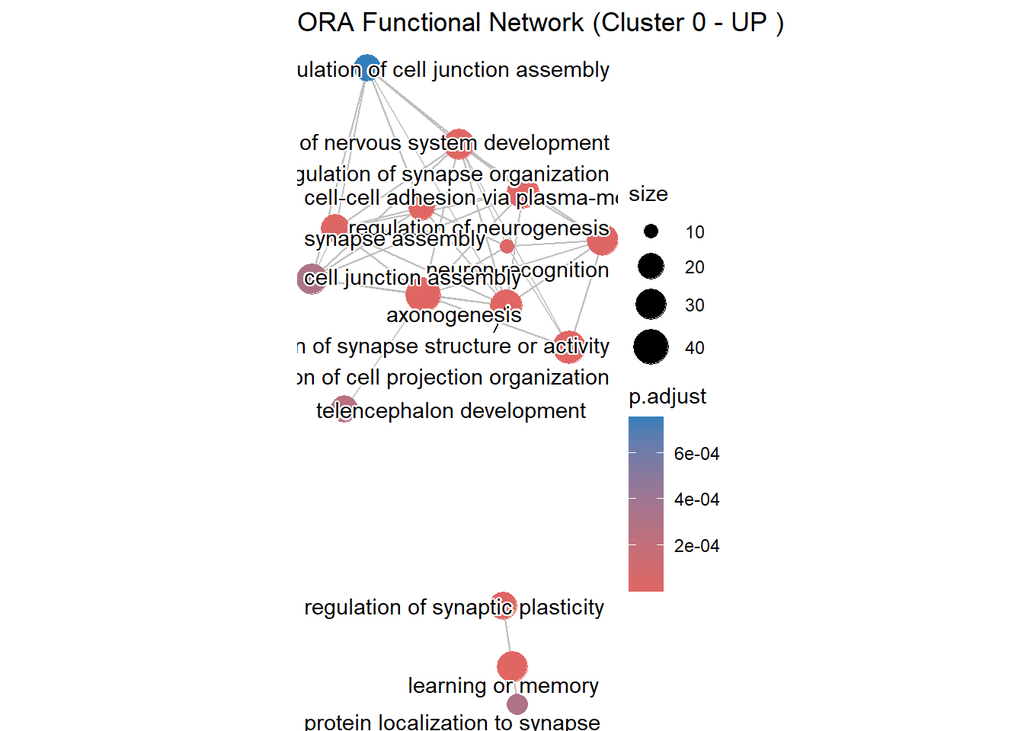

```r
# --- ORA HYPERPARAMETERS (Modify these to explore different results) ---
ORA_DIRECTION   <- "UP"   # Change to "DOWN" to study repressed functions, or "ALL"
ORA_ONTOLOGY    <- "BP"   # Change to "MF" (Molecular Function) or "CC" (Cellular Component)
ORA_LOG2FC_MIN  <- 0.5    # Minimum fold-change threshold
ORA_PADJ_CUTOFF <- 0.05   # FDR significance threshold
# -----------------------------------------------------------------------

# 1. Filter significant genes based on chosen direction and thresholds
ora_df <- result.DE %>% filter(cluster == target_cluster, p_val_adj < ORA_PADJ_CUTOFF)

if (ORA_DIRECTION == "UP") {
  ora_genes <- ora_df %>% filter(avg_log2FC > ORA_LOG2FC_MIN) %>% pull(gene)
} else if (ORA_DIRECTION == "DOWN") {
  ora_genes <- ora_df %>% filter(avg_log2FC < -ORA_LOG2FC_MIN) %>% pull(gene)
} else {
  ora_genes <- ora_df %>% filter(abs(avg_log2FC) > ORA_LOG2FC_MIN) %>% pull(gene)
}

# 2. Define background universe as all detected genes in the dataset (avoids tissue bias)
bg_genes <- rownames(sobj_filtrd)

# 3. Run ORA with the chosen ontology
ego_ora <- enrichGO(
  gene          = ora_genes,
  universe      = bg_genes,
  OrgDb         = org.Mm.eg.db,
  keyType       = "SYMBOL",
  ont           = ORA_ONTOLOGY,
  pAdjustMethod = "BH",
  pvalueCutoff  = 0.05,
  qvalueCutoff  = 0.05
)

# 4. Collapse redundant GO terms sharing >70% gene overlap and export plots
if (!is.null(ego_ora) && nrow(ego_ora@result %>% filter(p.adjust < 0.05)) > 0) {

  # simplify() clusters redundant terms to make the plots readable
  ego_ora_simp <- simplify(ego_ora, cutoff = 0.7, by = "p.adjust", select_fun = min)

  p_ora_dot <- dotplot(ego_ora_simp, showCategory = 15) +
    ggtitle(paste("ORA -", ORA_ONTOLOGY, "(Cluster", target_cluster, "-", ORA_DIRECTION, ")"))
  ggsave(file.path(plot_dir, "05_ORA_dotplot.png"), plot = p_ora_dot, width = 9, height = 7, dpi = 300)
  print(p_ora_dot)

  ego_ora_simp <- pairwise_termsim(ego_ora_simp)
  p_ora_emap <- emapplot(ego_ora_simp, showCategory = 15) +
    ggtitle(paste("ORA Functional Network (Cluster", target_cluster, "-", ORA_DIRECTION, ")"))
  ggsave(file.path(plot_dir, "06_ORA_emapplot.png"), plot = p_ora_emap, width = 9, height = 8, dpi = 300, bg = "white")
  print(p_ora_emap)

} else {
  warning("No significant GO terms found via ORA for cluster ", target_cluster, " (Direction: ", ORA_DIRECTION, ")")
}
```

### 3.2.3 Interpreting ORA Results

If the run was successful, two plots were saved in your *plots/* folder:

The **DotPlot** (*05_ORA_dotplot.png*): Similar to the Seurat DotPlot. The size of the dot represents the number of genes from your list involved in the term (count). The color represents the significance (p.adjust).

The **Enrichment Map** (*06_ORA_emapplot.png*): This network connects GO terms that share a lot of genes. It helps identify broader “themes” or families of functions.

### 3.2.4 Exercise:

*Q1 :* In the code above, the target_cluster parameter is set to “0”. Look at the annotation plot *03_DotPlot_canonical_markers.png*: this cluster strongly expresses markers for immature neurons (Dcx, Stmn2) and excitatory neurons (Satb2). Do the Biological Processes (BP) that emerge on your *ORA plot* confirm this neuronal identity?

*Q2 :* Change the `ORA_ONTOLOGY` parameter to “CC” (Cellular Component) and re-run the code block. Are the resulting terms (e.g., synapse, axon, or growth cone) consistent with the physical structure of a neuron?

*Q3 :* Try changing the `ORA_DIRECTION` parameter to `"DOWN"` and re-run the code to see which pathways Cluster 0 has repressed. To become a neuron, this cell had to permanently stop dividing. Do you see terms like “cell cycle” or “DNA replication” appearing in this suppressed list?

## 3.3 Gene Set Enrichment Analysis (GSEA)

**Objectives** : ORA (previous section) only looks at a list of genes selected with arbitrary cutoffs (FDR < 0.05, log2FC > 0.5). Every gene is either “in” or “out” of the list. Genes just below the cutoff are ignored, and so are coordinated but modest changes across many genes of the same pathway. GSEA (Subramanian *et al.*, PNAS 2005) does not use a threshold: it uses **all** the tested genes, ranked from the most up-regulated to the most down-regulated in the target cluster.

The principle :

- genes are ranked by a statistic (here the `avg_log2FC` of the target cluster against all the other cells)
- for each GO term, we walk down the ranked list. A running *Enrichment Score* (ES) goes up each time we meet a gene of the term and goes down otherwise. The ES is the maximum deviation from zero.
- the ES is normalized for the size of the gene set, which gives the **NES** (*Normalized Enrichment Score*)
  - NES > 0 : the genes of the term are at the top of the list (**activated** in the target cluster)
  - NES < 0 : the genes of the term are at the bottom of the list (**suppressed** in the target cluster)
- the significance is estimated by permutations (`fgsea` algorithm), then corrected for multiple testing (Benjamini-Hochberg)

We use the function `gseGO` from the `clusterProfiler` package (https://yulab-smu.top/biomedical-knowledge-mining-book/).

### 3.3.1 Build the ranked gene list

Recompute the differential expression between the target cluster and all the other cells, without any filter on the fold-change (`logfc.threshold = 0`). Up and down genes are both kept. We only remove the genes detected in less than 5% of the cells (`min.pct = 0.05`): their fold-change is dominated by dropout noise.

Run the code below (it can take a few minutes !)

```r
# 1. Compute unfiltered fold-changes (logfc.threshold = 0, both up & down genes)
#    min.pct = 0.05 removes extreme dropout noise (<5% expressing cells)
gsea_de <- FindMarkers(
  sobj_filtrd,
  ident.1         = target_cluster,
  ident.2         = NULL,
  logfc.threshold = 0,
  min.pct         = 0.05,
  verbose         = TRUE
)
```

[output not shown]

```r
# number of tested genes and distribution of the fold-changes
nrow(gsea_de)
```

```
[1] 10000
```

```r
summary(gsea_de$avg_log2FC)
```

```
    Min.  1st Qu.   Median     Mean  3rd Qu.     Max.
-7.99088 -0.36061 -0.09652 -0.29860  0.09697  3.36996
```

`gseGO` expects a **named numeric vector**, sorted in decreasing order. The values are the statistic and the names are the gene symbols.

```r
# 2. Rank all tested genes continuously by decreasing avg_log2FC
gene_list <- gsea_de$avg_log2FC
names(gene_list) <- rownames(gsea_de)
gene_list <- sort(gene_list, decreasing = TRUE)

# top and bottom of the ranked list
head(gene_list, 10)
```

```
    Ntf3    Cdh12    Satb2    Ndrg1  Fam19a2    Rbm24   Hs6st2   Clstn2
3.369955 2.869365 2.848054 2.694086 2.477293 2.465413 2.452428 2.418327
   Itpr1  Adamts2
2.368340 2.253245
```

```r
tail(gene_list, 10)
```

```
C130073E24Rik          Dgkg         Plce1           Sp9           Maf
    -6.415340     -6.430382     -6.433065     -6.805553     -6.914285
         Gad1         Nxph1          Gad2         Nrxn3        Dlgap5
    -7.205205     -7.233042     -7.481473     -7.493980     -7.990880
```

We rank 10,000 genes.

**Question** : look at the genes at the top and at the bottom of the list. Do they match the cell type you assigned to cluster 0 with the canonical markers (DotPlot) ?

Be aware: the ranking statistic is a choice. `avg_log2FC` measures the size of the effect but does not take its significance into account. A common alternative is `sign(avg_log2FC) * -log10(p_val)`. With thousands of cells, however, many p-values are equal to 0 and have to be capped. Both approaches are used in practice, and you can compare them.

### 3.3.2 Run GSEA on GO Biological Processes

The main parameters :

- `ont = "BP"` : we test the *Biological Process* ontology (alternatives : `"MF"`, `"CC"` or `"ALL"`)
- `keyType = "SYMBOL"` : our genes are named by their symbols (the rownames of the Seurat object)
- `minGSSize = 15`, `maxGSSize = 500` : very small terms are unstable and very large terms are too general to interpret, so both are excluded
- `pvalueCutoff = 0.05` : threshold applied to the **adjusted** p-value (`pAdjustMethod = "BH"`)
- `eps = 0` : the p-values are estimated exactly, even very small ones (by default they are bounded at 1e-10)
- `nPermSimple` : number of permutations of the first step of `fgsea` (1000 by default). Only increase it (e.g. 10000) if `fgsea` warns about *“unbalanced gene-level statistic values”*.

The test is based on random permutations, so we fix the seed for reproducibility.

```r
# 3. Fix seed before permutation testing and run GSEA (gene set size: 15 to 500)
set.seed(42)
gse_res <- gseGO(
  geneList      = gene_list,
  OrgDb         = org.Mm.eg.db,
  keyType       = "SYMBOL",
  ont           = "BP",
  minGSSize     = 15,
  maxGSSize     = 500,
  pvalueCutoff  = 0.05,
  pAdjustMethod = "BH",
  eps           = 0,
  #nPermSimple   = 10000,
  verbose       = FALSE
)
```

```
Warning in fgseaMultilevel(pathways = pathways, stats = stats, minSize =
minSize, : There were 12 pathways for which P-values were not calculated
properly due to unbalanced (positive and negative) gene-level statistic values.
For such pathways pval, padj, NES, log2err are set to NA. You can try to
increase the value of the argument nPermSimple (for example set it nPermSimple
= 10000)
```

```
Warning in fgseaMultilevel(pathways = pathways, stats = stats, minSize =
minSize, : For some of the pathways the P-values were likely overestimated. For
such pathways log2err is set to NA.
```

```r
# most significant terms and number of activated / suppressed terms
head(gse_res@result[, c("Description", "setSize", "NES", "p.adjust")], 10)
```

```
                                                    Description setSize
GO:0007059                               chromosome segregation     323
GO:0000280                                     nuclear division     287
GO:0098813                       nuclear chromosome segregation     235
GO:0048285                                    organelle fission     326
GO:0140014                             mitotic nuclear division     212
GO:0051301                                        cell division     472
GO:0000070                 mitotic sister chromatid segregation     159
GO:0000819                         sister chromatid segregation     193
GO:0008284 positive regulation of cell population proliferation     474
GO:0051276                              chromosome organization     441
                 NES     p.adjust
GO:0007059 -1.670104 1.841954e-19
GO:0000280 -1.677189 1.191183e-18
GO:0098813 -1.707365 1.211164e-17
GO:0048285 -1.628932 8.186014e-17
GO:0140014 -1.714931 4.313731e-16
GO:0051301 -1.544308 4.510705e-16
GO:0000070 -1.769914 1.340971e-15
GO:0000819 -1.712563 1.031013e-14
GO:0008284 -1.512861 2.321578e-13
GO:0051276 -1.508570 1.738051e-12
```

```r
table(ifelse(gse_res@result$NES > 0, "activated", "suppressed"))
```

```
 activated suppressed
         1        632
```

The results are stored in `gse_res@result`. In particular :

- `setSize` : number of genes of the term found in our ranked list
- `NES` : normalized enrichment score (its sign gives the direction)
- `p.adjust` : BH-adjusted p-value
- `core_enrichment` : the *leading edge*, i.e. the genes that contribute the most to the enrichment score. These are the genes to look at to interpret a term.

### 3.3.3 Visualisation

- **DotPlot** : the terms are split into activated (NES > 0) and suppressed (NES < 0). The x-axis (`GeneRatio`) is the fraction of the term’s genes that belong to the leading edge. The size of the dots is the number of leading-edge genes and the colour is the adjusted p-value.
- **Running Enrichment Score** (most significant term) :
  - top panel : the running ES along the ranked list. The peak (or the trough) gives the ES.
  - middle panel : each vertical bar is a gene of the term. Bars concentrated on the left mean activation, bars on the right mean suppression.
  - bottom panel : the value of the ranking statistic (`avg_log2FC`) along the list.

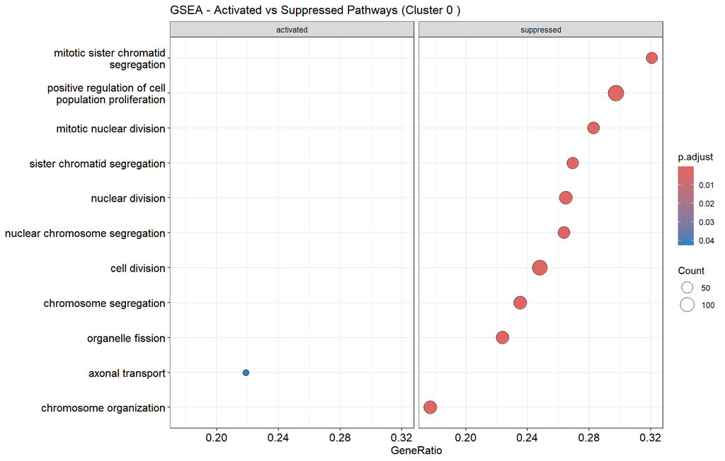

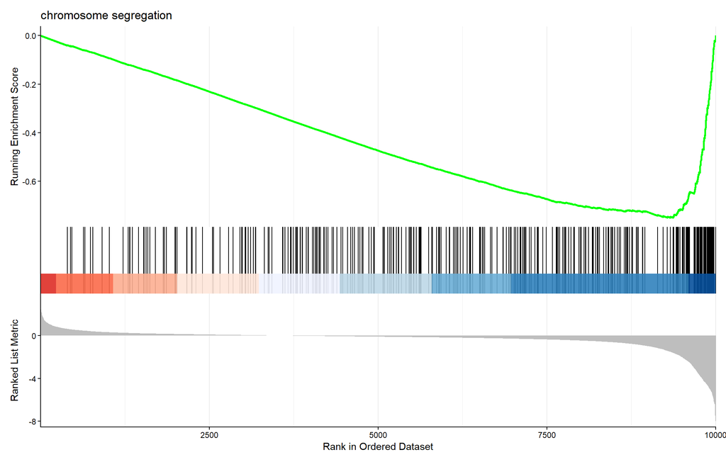

```r
# 4. Export GSEA split DotPlot and top pathway Running Enrichment Score curve
if (!is.null(gse_res) && nrow(gse_res@result) > 0) {
  p_gsea_dot <- dotplot(gse_res, showCategory = 10, split = ".sign") +
    facet_grid(. ~ .sign) +
    ggtitle(paste("GSEA - Activated vs Suppressed Pathways (Cluster", target_cluster, ")"))
  ggsave(file.path(plot_dir, "07_GSEA_dotplot.png"), plot = p_gsea_dot, width = 11, height = 7, dpi = 300)
  print(p_gsea_dot)

  p_gsea_curve <- gseaplot2(gse_res, geneSetID = 1, title = gse_res$Description[1])
  ggsave(file.path(plot_dir, "08_GSEA_running_score.png"), plot = p_gsea_curve, width = 9, height = 6, dpi = 300, bg = "white")
  print(p_gsea_curve)
} else {
  warning("No significant GO terms found via GSEA for cluster ", target_cluster)
}
```

**Question** : which biological processes are activated and which are suppressed in cluster 0 ? Are they consistent with the ORA results and with the cell type you identified ?

Be aware:

- we compare the target cluster to **all the other cells**, which form a heterogeneous mixture of cell types. A “suppressed” term (e.g. cell division) does not mean the process is switched off. It means that it is **less** active than in the other clusters on average (here, the cycling progenitors).
- GO terms are highly redundant (e.g. *nuclear division*, *mitotic nuclear division*, *chromosome segregation*): several significant terms often reflect the same set of genes. As for ORA, `simplify(gse_res, cutoff = 0.7)` can be used to merge them.

# 4 Save

```r
# Save ORA and GSEA outputs for future reference
if (exists("ego_ora") && !is.null(ego_ora)) {
  saveRDS(ego_ora, file.path(cache_dir, paste0("ORA_results_cluster", target_cluster, ".rds")))
}
if (exists("gse_res") && !is.null(gse_res)) {
  saveRDS(gse_res, file.path(cache_dir, paste0("GSEA_results_cluster", target_cluster, ".rds")))
}
message("Results successfully saved in ", cache_dir)
```

```
Results successfully saved in D:/BMC -AIDA RNA Seq-Analysis/OSTA/data/processed_data
```